# Caso de estudio de minería de datos

Minería de datos

Autor: Jordi Gironés Roig  
Coordinación: Julià Minguillón Alfonso

### Estudiante: Erika Paola Martínez Soria

## PEC 1

### Ejercicio 1.

Propón un proyecto completo de minería de datos. La organización de la respuesta tiene que coincidir en las fases típicas del ciclo de vida de un proyecto de minería de datos. **No hay que realizar las tareas de la fase**. Para cada fase indica cuál es el objetivo de la fase y el producto que se obtendrá. Utiliza ejemplos de qué y cómo podrían ser las tareas. Si hay alguna característica que hace diferente el ciclo de vida de un proyecto de minería respecto a otros proyectos indícalo.

### Respuesta:

La encuesta de Kaggle denominada 2021 Kaggle Machine Learning & Data Science Survey (Kaggle, 2021a) abarca temas como el perfil del científico de datos, su educación, la experiencia en aprendizaje automático y ciencia de datos y situación laboral, obteniendo respuestas de alrededor de 25 000 data scientists alrededor del mundo.

Nuestro objetivo con este proyecto de minería de datos es el de describir los factores determinantes en el ingreso anual de un data scientist a partir de diversas variables encontradas en el conjunto de datos, como, por ejemplo: género, país de residencia, nivel de educación, cargo específico, años escribiendo código, número de empleados en la compañía en que trabaja, número de empleados en el equipo de analítica, herramientas que utilizan diariamente, etc. La descripción lo hacemos con el fin de encontrar asociaciones significativas o causales entre las diferentes variables.

Después de haber establecido el objetivo analítico, nos encargamos de la preparación de los datos. En un primer paso, Kaggle ya ha realizado parte de la limpieza del conjunto de datos. Según el documento de la metodología de la encuesta, para asegurar la calidad de los datos, se excluyó a las encuestas que el sistema detectó como “Spam” o “Duplicado”, también se eliminó las respuestas de los encuestados que tardaron menos de dos minutos, así como las que seleccionaron menos de 15 opciones de respuesta (Kaggle, 2021b). De esta manera, ya encargándose de los datos incompletos y redundantes, parte del proceso de limpieza faltante sería el encargarse de revisar los datos incorrectos o inconsistentes y errores de transcripción. La otra sub-fase de preparación de datos es la transformación, la cual tiene el fin de poner los datos en una forma adecuada para la futura aplicación del modelo. En el proyecto podría ser que necesitemos transformar las variables categóricas y numéricas a valores binarios (Rasinen, citado en Andrew, 2012) en el caso de que usemos redes bayesianas. En el caso de la reducción de dimensionalidad, el cual utilizamos para reducir el número de atributos y registros del conjunto de datos para mejorar la eficiencia del algoritmo de minería de datos, el proyecto necesitaría pasar de tener 368 atributos a un número que refleje los más relevantes para su utilización en el modelo descriptivo. Por ejemplo, podría determinarse que la variable con el tipo de hardware especializado que utiliza un científico de datos tenga menos importancia que la variable con el país de origen, por lo tanto, se lo puede descartar.

Finalizada la fase de preparación de los datos, la cual deja los datos con la calidad adecuada, entramos en la fase de construcción de modelos. Esta fase la conceptualizamos como un proceso de búsqueda del mejor modelo que debe estar basada en los datos que tenemos y el conocimiento a priori (Minguillón, 2016). Por ejemplo, sabemos que países desarrollados ofrecen un mayor salario que países en desarrollo, por lo que asumimos que la variable de ingreso debe tener asociación significativa con el país de residencia. Utilizando los modelos disponibles para nuestro objetivo analítico, los que pueden ser redes bayesianas o las reglas de asociación, escogemos el modelo que exprese mejor esta relación. En la sub-fase de evaluación e interpretación del modelo, donde medimos la calidad del modelo, utilizaríamos la mitad de los 25000 registros para construir el modelo y el resto para evaluarlo. Esto lo realizamos con el objetivo de medir hasta que punto se ajustan al dominio descrito (Minguillón, 2016).

### Bibliografia

Andrew. (2021, Marzo 25). Continuous variables in Bayesian networks. https://statmodeling.stat.columbia.edu/2012/03/25/continuous-variables-in-bayesian-networks/

Kaggle (2021). 2021 Kaggle Machine Learning & Data Science Survey. https://www.kaggle.com/c/kaggle-survey-2021/overview

Kaggle (2021). kaggle_survey_2021_methodology. https://www.kaggle.com/c/kaggle-survey-2021/data?select=supplementary_data

Minguillón, Julià & Caihuelas, Ramon (2016). “Proceso de minería de datos.”. Editorial UOC.

### Ejercicio 2:

A partir del juego de datos utilizado en el ejemplo anterior, realiza las tareas previas a la generación de un modelo de minería de datos explicadas en los módulos "El proceso de minería de datos" y "Preprocesado de los datos y gestión de características". Puedes utilizar de referencia el ejemplo anterior, pero procura cambiar el enfoque y analizar los datos en función de las diferentes dimensiones que presentan los datos.

```python
#Importar las librerias

import pandas as pd
import numpy as np
from matplotlib import pyplot as plt
import seaborn as sns
import sklearn
```

```python
# Accedemos al fichero accident.csv
filename = 'accident.CSV'

accidentData = pd.read_csv(filename, encoding = "ISO-8859-1")
accidentData
```

```
C:\Users\Erika Martinez\AppData\Local\Temp\ipykernel_12740\530963771.py:4: DtypeWarning: Columns (40,42,69) have mixed types. Specify dtype option on import or set low_memory=False.
  accidentData = pd.read_csv(filename, encoding = "ISO-8859-1")
```

|  | STATE | STATENAME | ST_CASE | VE_TOTAL | VE_FORMS | PVH_INVL | PEDS | PERSONS | PERMVIT | PERNOTMVIT | ... | HOSP_MN | HOSP_MNNAME | CF1 | CF1NAME | CF2 | CF2NAME | CF3 | CF3NAME | FATALS | DRUNK_DR |
| --- | --- | --- | --- | --- | --- | --- | --- | --- | --- | --- | --- | --- | --- | --- | --- | --- | --- | --- | --- | --- | --- |
| 0 | 1 | Alabama | 10001 | 2 | 2 | 0 | 0 | 3 | 3 | 0 | ... | 27 | 27 | 0 | None | 0 | None | 0 | None | 1 | 1 |
| 1 | 1 | Alabama | 10002 | 2 | 2 | 0 | 0 | 2 | 2 | 0 | ... | 99 | Unknown EMS Hospital Arrival Time | 0 | None | 0 | None | 0 | None | 1 | 0 |
| 2 | 1 | Alabama | 10003 | 3 | 3 | 0 | 0 | 4 | 4 | 0 | ... | 5 | 5 | 14 | Motor Vehicle struck by falling cargo,or somet... | 0 | None | 0 | None | 1 | 0 |
| 3 | 1 | Alabama | 10004 | 1 | 1 | 0 | 1 | 1 | 1 | 1 | ... | 88 | Not Applicable (Not Transported) | 0 | None | 0 | None | 0 | None | 1 | 0 |
| 4 | 1 | Alabama | 10005 | 1 | 1 | 0 | 0 | 1 | 1 | 0 | ... | 88 | Not Applicable (Not Transported) | 0 | None | 0 | None | 0 | None | 1 | 1 |
| ... | ... | ... | ... | ... | ... | ... | ... | ... | ... | ... | ... | ... | ... | ... | ... | ... | ... | ... | ... | ... | ... |
| 33239 | 56 | Wyoming | 560117 | 1 | 1 | 0 | 0 | 1 | 1 | 0 | ... | 99 | Unknown EMS Hospital Arrival Time | 0 | None | 0 | None | 0 | None | 1 | 0 |
| 33240 | 56 | Wyoming | 560118 | 5 | 5 | 0 | 0 | 6 | 6 | 0 | ... | 0 | 0 | 0 | None | 0 | None | 0 | None | 1 | 0 |
| 33241 | 56 | Wyoming | 560119 | 1 | 1 | 0 | 0 | 1 | 1 | 0 | ... | 21 | 21 | 0 | None | 0 | None | 0 | None | 1 | 1 |
| 33242 | 56 | Wyoming | 560120 | 1 | 1 | 0 | 0 | 2 | 2 | 0 | ... | 52 | 52 | 0 | None | 0 | None | 0 | None | 1 | 1 |
| 33243 | 56 | Wyoming | 560121 | 2 | 2 | 0 | 0 | 3 | 3 | 0 | ... | 2 | 2 | 0 | None | 0 | None | 0 | None | 2 | 1 |

33244 rows × 91 columns

### Exploración del conjunto de datos

Verificamos la estructura del juego de datos principal.

Obtenemos el numero de filas y columnas del conjunto de datos.

```python
accidentData.shape
```

```
(33244, 91)
```

Vemos el número de columnas que tenemos y sus nombres.

```python
accidentData.info()
```

```
<class 'pandas.core.frame.DataFrame'>
RangeIndex: 33244 entries, 0 to 33243
Data columns (total 91 columns):
 #   Column        Non-Null Count  Dtype
---  ------        --------------  -----
 0   STATE         33244 non-null  int64
 1   STATENAME     33244 non-null  object
 2   ST_CASE       33244 non-null  int64
 3   VE_TOTAL      33244 non-null  int64
 4   VE_FORMS      33244 non-null  int64
 5   PVH_INVL      33244 non-null  int64
 6   PEDS          33244 non-null  int64
 7   PERSONS       33244 non-null  int64
 8   PERMVIT       33244 non-null  int64
 9   PERNOTMVIT    33244 non-null  int64
```

[output cut: 83 more lines]

Vemos que tenemos **91** variables y **33244** registros

Revisamos la descripción de las variables contenidas en el fichero y si los tipos de variables se corresponden con las que hemos cargado. Las organizamos lógicamente para darles sentido y construimos un pequeño diccionario de datos utilizando la documentación auxiliar.

- **ST_CASE** identificador de accidente
- **FATAL** muertes
- **DRUNK_DR** conductores bebidos
- **VE_TOTAL** número de vehículos implicados en total
- **VE_FORMS** número de vehículos en movimiento implicados
- **PVH_INVL** número de vehículos estacionados implicados
- **PEDS** número de peatones implicados
- **PERSONS** número de ocupante de vehículo implicados
- **PERMVIT** número conductores y ocupantes implicados
- **PERNOTMVIT** número peatones, ciclistas, a caballo... Cualquier cosa menos vehículo motorizado

**DIMENSIÓN GEOGRÁFICA**

- **STATE** codificación de estado
- **STATENAME** nombre de estado
- **COUNTY** identificador de contado
- **COUNTYNAME** condado
- **CITY** identificador de ciudad
- **CITYNAME** ciudad
- **NHS** 1 ha pasado a autopista del NHS 0 no
- **NHSNAME** TBD
- **ROUTE** identificador de ruta
- **ROUTENAME** ruta
- **TWAY_ID** vía de tránsito (1982)
- **TWAY_ID2** vía de tránsito (2004)
- **RUR_URB** identificador de segmento rural o urbano
- **RUR_URBNAME** segmento rural o urbano
- **FUNC_SYS** clasificación funcional segmento
- **FUNC_SYSNAME** TBD
- **RD_OWNER** identificador propietario del segmento
- **RD_OWNERNAME** propietario del segmento
- **MILEPT** milla int
- **MILEPTNAME** milla chr
- **LATITUDE** latitud int
- **LATITUDENAME** latitud chr
- **LONGITUD** longitud int
- **LONGITUDNAME** longitud chr
- **SP_JUR** código jurisdicción
- **SP_JURNAME** jurisdicción

**DIMENSIÓN TEMPORAL**

- **DAY** día
- **DAYNAME** día repetido
- **MONTH** mes
- **MONTHNAME** nombre de mes
- **YEAR** año
- **DAY_WEEK** día de la semana
- **DAY_WEEKNAME** nombre de día de la semana
- **HOUR** hora
- **HOURNAME** franja hora
- **MINUTE** minuto int
- **MINUTENAME** minuto chr

**DIMENSIÓN CONDCICIONS ACCIDENTE**

- **HARM_EV** código primero acontecimiento del accidente que produzca daños o lesiones
- **HARM_EVNAME** primer acontecimiento del accidente que produzca daños o lesiones
- **MAN_COLL** código de posición de los vehículos
- **MAN_COLLNAME** posición de los vehículos
- **RELJCT1** código si hay área de intercambio
- **RELJCT1NAME** si hay área de intercambio
- **RELJCT2** código proximidad cruce
- **RELJCT2NAME** proximidad cruce
- **TYP_INT** código tipo de intersección
- **TYP_INTNAME** tipo de intersección
- **WRK_ZONE** código tipología de obras
- **WRK_ZONENAME** tipología de obras
- **RAIL_ROAD** código ubicación vehículo a la vía
- **RAIL_ROADNAME** ubicación vehículo a la vía
- **LGT_COND** código condición lumínica
- **LGT_CONDNAME** condición lumínica

**DIMENSIÓN METEREOLOGIA**

- **WEATHER1** código tiempo
- **WEATHER1NAME** tiempo
- **WEATHER2** código tiempo adicional
- **WEATHER2NAME** tiempo adicional
- **WEATHER** código tiempo hasta 2006
- **WEATHERNAME** tiempo hasta 2006

**OTROS**

- **SCH_BUSS** código si vehículo escolar implicado
- **SCH_BUSNAME** vehículo escolar implicado
- **RAIL** código si dentro o cerca paso ferroviario
- **RAILNAME** si dentro o cerca paso ferroviario

*DIMENSIÓN SERVICIO EMERGENCIES**

- **NOT_HOUR** hora notificación a emergencias int
- **NOT_HOURNAME** hora notificación a emergencias franja
- **NOT_MIN** minuto notificación a emergencias int
- **NOT_MINNAME** minuto notificación a emergencias chr
- **ARR_HOUR** hora llegada emergencias int
- **ARR_HOURNAME** hora llegada emergencias franja
- **ARR_MIN** minuto llegada emergencias int
- **ARR_MINNAME** minuto llegada emergencias franja
- **HOSP_HR** hora llegada hospital int
- **HOSP_HRNAME** hora llegada hospital franja
- **HOSP_MN** minuto llegada hospital int
- **HOSP_MNNAME** minuto llegada hospital franja

*DIMENSIÓN FACTORES RELACIONADOS ACCIDENTE*

- **CF1** código factores relacionados con el accidente 1
- **CF1NAME** factores relacionados con el accidente 1
- **CF2** código factores relacionados con el accidente 2
- **CF2NAME** factores relacionados con el accidente 2
- **CF3** código factores relacionados con el accidente 3

## Preprocesamiento y gestión de características

### Limpieza

El siguiente paso será la limpieza de datos, mirando si hay valores vacíos o nulos.

```python
print("NA")
accidentData.isnull().sum()
```

```
NA
```

```
STATE        0
STATENAME    0
ST_CASE      0
VE_TOTAL     0
VE_FORMS     0
            ..
CF2NAME      0
CF3          0
CF3NAME      0
FATALS       0
DRUNK_DR     0
Length: 91, dtype: int64
```

No hay valores nulos en los datos, excepto en la columna TWAY_ID2

Al haber ya analizado, en el ejemplo dado, la distribución de número de muertes, ahora visualizamos la distribución de los peatones implicados en accidentes.

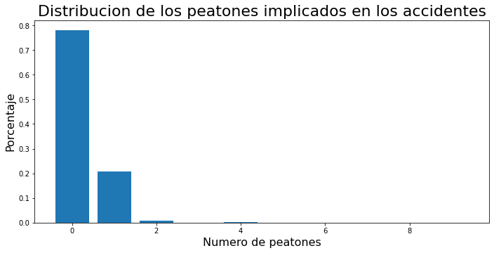

```python
#Bar chart de porcentaje de numero de peatones implicados

fig = plt.figure()
ax = fig.add_axes([0,0,1.5,1])

perc_peatones = accidentData.groupby(["PEDS"]).size() / len(accidentData["PEDS"])
valores_peatones = accidentData["PEDS"].unique()

ax.bar(valores_peatones, perc_peatones)

plt.title("Distribucion de los peatones implicados en los accidentes", fontsize=22)
plt.xlabel('Numero de peatones', fontsize=16)
plt.ylabel('Porcentaje', fontsize=16)

plt.show()
```

Sabemos, gracias al ejemplo, que la mayoría de los accidentes tienen como mínimo un muerto. Pero los accidentes en su mayoría parecen no implicar a peatones. Como muestra la gráfica, cerca del 80% de los accidentes tienen 0 peatones implicados, seguido por alrededor de 20% con solo un peaton implicado.

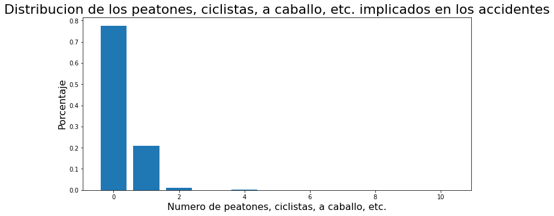

```python
#Bar chart de porcentaje de numero de peatones implicados

fig = plt.figure()
ax = fig.add_axes([0,0,1.5,1])

perc_peatones = accidentData.groupby(["PERNOTMVIT"]).size() / len(accidentData["PERNOTMVIT"])
valores_peatones = accidentData["PERNOTMVIT"].unique()

ax.bar(valores_peatones, perc_peatones)

plt.title("Distribucion de los peatones, ciclistas, a caballo, etc. implicados en los accidentes", fontsize=22)
plt.xlabel('Numero de peatones, ciclistas, a caballo, etc.', fontsize=16)
plt.ylabel('Porcentaje', fontsize=16)

plt.show()
```

De manera similiar al gráfico de distribución de peatones implicados en accidentes, podemos ver que la distribución de peatones, ciclistas, a caballo, etc. no varía significativamente. Mostrando que en su mayoría, los accidentes tienen cero personajes involucrados, exceptuando obviamente los motorizados. Esto tiene sentido, dado la naturaleza de los datos, los cuales están enfocados en Highways.

Visualizamos la distribución de los vehiculos implicados en accidentes.

```python
#Porcentaje proporcion de vehiculos involucrados en accidentes.
accidentData.groupby(["VE_TOTAL"]).size() / len(accidentData["VE_TOTAL"])
```

```
VE_TOTAL
1     0.547377
2     0.367044
3     0.061816
4     0.014439
5     0.005505
6     0.001805
7     0.001053
8     0.000421
9     0.000150
10    0.000030
11    0.000060
12    0.000120
16    0.000060
19    0.000030
24    0.000030
28    0.000030
59    0.000030
dtype: float64
```

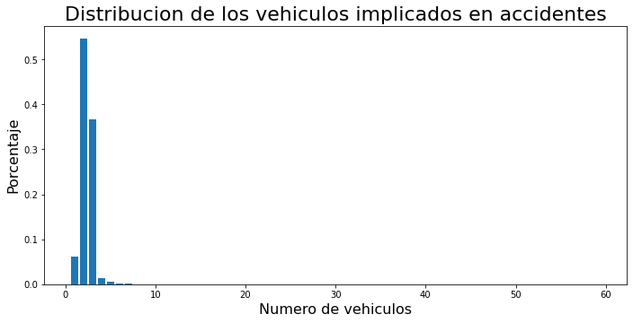

```python
#Bar chart de porcentaje de numero de vehiculos implicados

fig = plt.figure()
ax = fig.add_axes([0,0,1.5,1])

perc_vehiculos = accidentData.groupby(["VE_TOTAL"]).size() / len(accidentData["VE_TOTAL"])
valores_vehiculos = accidentData["VE_TOTAL"].unique()

ax.bar(valores_vehiculos, perc_vehiculos)

plt.title("Distribucion de los vehiculos implicados en accidentes", fontsize=22)
plt.xlabel('Numero de vehiculos', fontsize=16)
plt.ylabel('Porcentaje', fontsize=16)

plt.show()
```

Podemos visualizar que la mayoría de los accidentes (55%) tienen solo un vehículo implicado, seguido con el 37% de los casos en el que dos vehiculos se vieron implicados. En este caso, sería interesante saber las razones del porque la mayoría de accidentes solo implican un vehículo, ya que va en contra del sentido común.

Vemos el numero de muertos dependiendo del tipo de intersección en el que ocurrió el accidente.

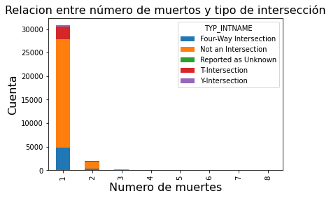

```python
#Seleccionamos las 5 tipos de intersecciones donde han sucedido mas accidentes
intersecciones = accidentData['TYP_INTNAME'][ (accidentData['TYP_INTNAME'] == "Not an Intersection") | (accidentData['TYP_INTNAME'] == "Four-Way Intersection") | (accidentData['TYP_INTNAME'] == "T-Intersection") | (accidentData['TYP_INTNAME'] == "Y-Intersection") | (accidentData['TYP_INTNAME'] == "Reported as Unknown")]

#Creamos un crosstable con las variables de las muertes y de los tipos de intersecciones
cross_fatals_intersection = pd.crosstab(accidentData["FATALS"], intersecciones)

#Creamos el steacked bar graph
ax = cross_fatals_intersection.plot.bar(stacked=True)
ax.set_title("Relacion entre número de muertos y tipo de intersección", size = 16)
ax.set_xlabel("Numero de muertes", size = 16)
ax.set_ylabel("Cuenta", size = 16)
```

En esta gráfica podemos ver que la mayoría de muertes no se producen en una intersección, por lo que podemos concluir que al menos este tipo de infrasestructura en carreteras no influye en la mayoría de accidentes. Sin embargo, la interseccion de 4 vías le sigue en el número de accidentes ocurridos.

Vemos el numero de muertos dependiendo de proximidad el cruce en el que ocurrió el accidente.

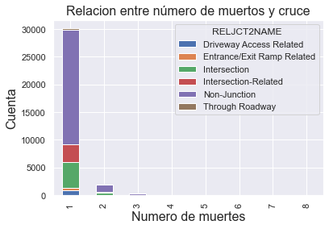

```python
#Seleccionamos las 5 tipos de cruces donde han sucedido mas accidentes
cruces = accidentData['RELJCT2NAME'][ (accidentData['RELJCT2NAME'] == "Non-Junction") | (accidentData['RELJCT2NAME'] == "Intersection") | (accidentData['RELJCT2NAME'] == "Intersection-Related") | (accidentData['RELJCT2NAME'] == "Driveway Access Related") | (accidentData['RELJCT2NAME'] == "Entrance/Exit Ramp Related") | (accidentData['RELJCT2NAME'] == "Driveway Access Related") | (accidentData['RELJCT2NAME'] == "Entrance/Exit Ramp Related") | (accidentData['RELJCT2NAME'] == "Through Roadway")]

#Creamos un crosstable con las variables de las muertes y de los cruces
cross_fatals_cruces = pd.crosstab(accidentData["FATALS"], cruces)

#Creamos el steacked bar graph
ax = cross_fatals_cruces.plot.bar(stacked=True)

ax.set_title("Relacion entre número de muertos y cruce", size = 16)
ax.set_xlabel("Numero de muertes", size = 16)
ax.set_ylabel("Cuenta", size = 16)
```

De manera similar al anterior gráfico, vemos que los accidentes no occuren cerca de un cruce. Pero si es el caso, de que un numero menor de accidentes ocurren en intersecciones o relacionada con intersecciones.

Ahora analizamos los accidentes desde la perspectiva temporal.

En la siguiente gráfica, vemos el número de accidentes por hora del día

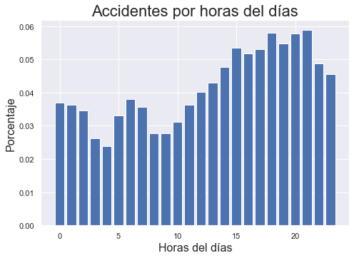

```python
#Observamos que hay un 99 en los valores de las horas. Existe un error o el numero 99 significa algo diferente.
accidentData["HOUR"].unique()

#Vemos que hay 249 con el valor 99 como hora.
accidentData["HOUR"][accidentData["HOUR"] == 99]

#No tamamos en cuenta las filas con los valores con 99
df_sin_99 = accidentData[accidentData["HOUR"] != 99]

#Hacemos una lista con las horas del días ordenadas ascendentemente
horas = list(df_wo_99["HOUR"].unique())
horas_ordenadas = sorted(horas)


#Creamos la figura
fig = plt.figure()
ax = fig.add_axes([0,0,1,1])

perc_dayweek = df_sin_99.groupby(["HOUR"]).size() / len(df_sin_99["HOUR"])
dias = horas_ordenadas

ax.bar(dias, perc_dayweek)

plt.title("Accidentes por horas del días", fontsize=22)
plt.xlabel('Horas del días', fontsize=16)
plt.ylabel('Porcentaje', fontsize=16)

plt.show()
```

Reconocemos que hay 249 filas con el valor de 99 en la variable HOUR, esto puede ser un error o el valor 99 tiene un significado determinado. En este caso, decidimos no usar las 249 filas con el valor 99, y analizamos el resto.

Como se puede observar los accidentes de tránsito van incrementado a medida que se acerca la tarde y noche. Este gráfico nos permite desglosar un poco más el análisis del ejemplo, en donde se discretizaron los valores de acuerdo a intervalor de igual amplitud (madrugada, mañana, mediodia, anochecer, noche).

A continuación vemos el número de accidentes por día de la semana.

```python
accidentData.groupby(["DAY_WEEKNAME"]).size() / len(accidentData["DAY_WEEKNAME"])
```

```
DAY_WEEKNAME
Friday       0.157983
Monday       0.130791
Saturday     0.168451
Sunday       0.152990
Thursday     0.133708
Tuesday      0.128895
Wednesday    0.127181
dtype: float64
```

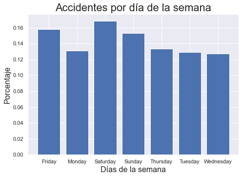

```python
#Bar chart de porcentaje de numero de accidentes por día de la semana

fig = plt.figure()
ax = fig.add_axes([0,0,1,1])

perc_dayweek = accidentData.groupby(["DAY_WEEKNAME"]).size() / len(accidentData["DAY_WEEKNAME"])
dias = ["Friday", "Monday", "Saturday", "Sunday", "Thursday", "Tuesday", "Wednesday"]

plt.bar(dias, perc_dayweek)

plt.title("Accidentes por día de la semana", fontsize=22)
plt.xlabel('Días de la semana', fontsize=16)
plt.ylabel('Porcentaje', fontsize=16)

plt.show()
```

Veamos los conductores bebidos y no bebidos por cada día de la semana.

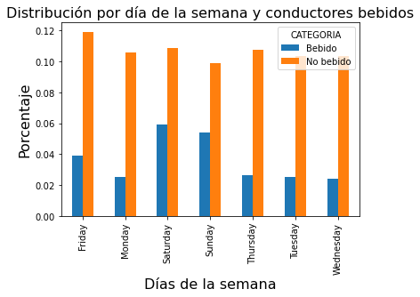

```python
#Copiamos la columna DRUNK_DR en una nueva columna CATEGORIA
accidentData["CATEGORIA"] = accidentData["DRUNK_DR"]

#Reemplazamos los valores 1,2,3,4 con la categoria Bebido
accidentData_drink = accidentData["CATEGORIA"].replace([1, 2, 3, 4], "Bebido")

#Reemplazamos el valor 0 con la categoria No bebido
accidentData_drink = accidentData_drink.replace(0, "No bebido")

#Crosstab de las variables con los dias de la semana y con los conductores bebidos o no bebidos.
crosstab = pd.crosstab(accidentData_drink, accidentData['DAY_WEEKNAME'])

#Con .T los subconjuntos van en las columnas, y los conjuntos superiores estan en las filas.
df = crosstab
df = df.T  #.T : Cambia el orden, las columnas por filas y viceversa.
df = df / len(accidentData_drink) #Dividimos para ponerlos en porcentajes

#Dibujamos la crosstable
ax = df.plot.bar()

ax.set_title("Distribución por día de la semana y conductores bebidos", size = 16)
ax.set_xlabel("Días de la semana", size = 16)
ax.set_ylabel("Porcentaje", size = 16)


#accidentData.drop(columns=['CATEGORIA'], inplace=True)
```

Podemos en un comienzo intuir que habrá más conductores bebidos los fines de semana, y en efecto, así es el caso. El día donde hay más conductores bebidos involucrados en accidentes es el día sábado, seguido por el domingo, y en tercer lugar el viernes. En el caso de conductores no bebidos, el máximo porcentaje se encuentra el día viernes y el porcentaje más pequeño el día domingo.

Visualizamos el porcentaje de accidentes de acuerdo al mes.

```python
accidentData.groupby(["MONTHNAME"]).size() / len(accidentData["MONTHNAME"])
```

```
MONTHNAME
April        0.078480
August       0.092739
December     0.080195
February     0.066177
January      0.074359
July         0.091054
June         0.087685
March        0.076405
May          0.087565
November     0.084436
October      0.088557
September    0.092347
dtype: float64
```

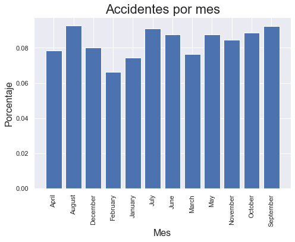

```python
#Bar chart de porcentaje de numero de accidentes por mes

fig = plt.figure()
ax = fig.add_axes([0,0,1,1])

perc_dayweek = accidentData.groupby(["MONTHNAME"]).size() / len(accidentData["MONTHNAME"])
dias = ["April","August", "December",  "February","January","July", "June", "March", "May", "November","October", "September"]

ax.bar(dias, perc_dayweek)

plt.title("Accidentes por mes", fontsize=22)
plt.xlabel('Mes', fontsize=16)
plt.xticks(rotation=90)
plt.ylabel('Porcentaje', fontsize=16)

plt.show()
```

De acuerdo al mes, el porcentaje de accidentes muestra que en el mes de febrero es donde menos accidentes suceden, y en el mes de agosto y septiembre donde hay mas accidentes.

Revisamos el numero de muertos de acuerdo a los 3 estados con mas accidentes (Florida, California, Texas) y al mes en que suceden.

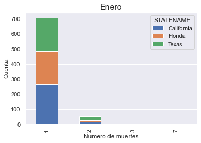

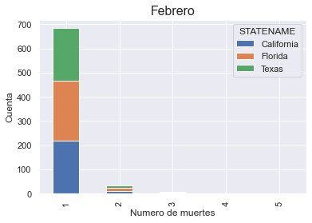

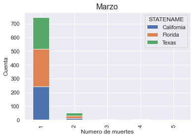

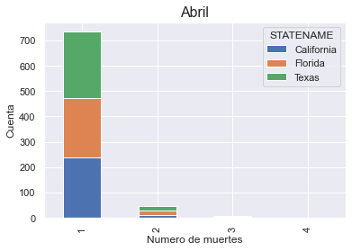

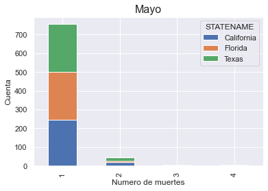

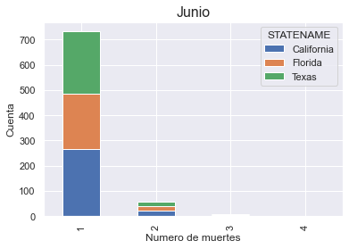

[figure not shown]

[figure not shown]

[figure not shown]

[figure not shown]

[figure not shown]

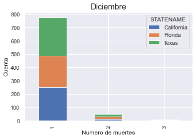

```python
#Seleccionamos los estados que queremos analizar
estados_select = accidentData[['FATALS', 'STATENAME', 'MONTHNAME']][ (accidentData['STATENAME'] == "Texas")  | (accidentData['STATENAME'] == "Florida") | (accidentData['STATENAME'] == "California")]

#Enero
df = estados_select[estados_select['MONTHNAME'] == "January"].groupby(['FATALS','STATENAME']).size()
df.unstack().plot.bar(stacked=True)
plt.title("Enero", fontsize= 16)
plt.xlabel("Numero de muertes")
plt.ylabel("Cuenta")

#Febrero
df = estados_select[estados_select['MONTHNAME'] == "February"].groupby(['FATALS','STATENAME']).size()
df.unstack().plot.bar(stacked=True)
plt.title("Febrero",fontsize= 16)
plt.xlabel("Numero de muertes")
plt.ylabel("Cuenta")

#Marzo
df = estados_select[estados_select['MONTHNAME'] == "March"].groupby(['FATALS','STATENAME']).size()
df.unstack().plot.bar(stacked=True)
plt.title("Marzo",fontsize= 16)
plt.xlabel("Numero de muertes")
plt.ylabel("Cuenta")

#Abril
df = estados_select[estados_select['MONTHNAME'] == "April"].groupby(['FATALS','STATENAME']).size()
df.unstack().plot.bar(stacked=True)
plt.title("Abril",fontsize= 16)
plt.xlabel("Numero de muertes")
plt.ylabel("Cuenta")

#Mayo
df = estados_select[estados_select['MONTHNAME'] == "May"].groupby(['FATALS','STATENAME']).size()
df.unstack().plot.bar(stacked=True)
plt.title("Mayo",fontsize= 16)
plt.xlabel("Numero de muertes")
plt.ylabel("Cuenta")

#Junio
df = estados_select[estados_select['MONTHNAME'] == "June"].groupby(['FATALS','STATENAME']).size()
df.unstack().plot.bar(stacked=True)
plt.title("Junio",fontsize= 16)
plt.xlabel("Numero de muertes")
plt.ylabel("Cuenta")

#Julio
df = estados_select[estados_select['MONTHNAME'] == "July"].groupby(['FATALS','STATENAME']).size()
df.unstack().plot.bar(stacked=True)
plt.title("Agosto",fontsize= 16)
plt.xlabel("Numero de muertes")
plt.ylabel("Cuenta")

#Agosto
df = estados_select[estados_select['MONTHNAME'] == "August"].groupby(['FATALS','STATENAME']).size()
df.unstack().plot.bar(stacked=True)
plt.title("Septiembre",fontsize= 16)
plt.xlabel("Numero de muertes")
plt.ylabel("Cuenta")

#Septiembre
df = estados_select[estados_select['MONTHNAME'] == "September"].groupby(['FATALS','STATENAME']).size()
df.unstack().plot.bar(stacked=True)
plt.title("Octubre",fontsize= 16)
plt.xlabel("Numero de muertes")
plt.ylabel("Cuenta")

#Octubre
df = estados_select[estados_select['MONTHNAME'] == "October"].groupby(['FATALS','STATENAME']).size()
df.unstack().plot.bar(stacked=True)
plt.title("Febrero",fontsize= 16)
plt.xlabel("Numero de muertes")
plt.ylabel("Cuenta")

#Noviembre
df = estados_select[estados_select['MONTHNAME'] == "November"].groupby(['FATALS','STATENAME']).size()
df.unstack().plot.bar(stacked=True)
plt.title("Febrero",fontsize= 16)
plt.xlabel("Numero de muertes")
plt.ylabel("Cuenta")

#Diciembre
df = estados_select[estados_select['MONTHNAME'] == "December"].groupby(['FATALS','STATENAME']).size()
df.unstack().plot.bar(stacked=True)
plt.title("Diciembre",fontsize= 16)
plt.xlabel("Numero de muertes")
plt.ylabel("Cuenta")
```

Parece existir ligera variabilidad de accidentes de acuerdo a los meses en los tres diferentes estados.

Ahora analicemos los datos en términos geográficos.

Vemos el numero de accidentes basado en si este estaba ubicado en un área rural o urbana.

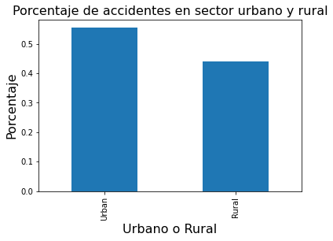

```python
#Contamos los accidentes en areas rurales y urbanas
rural_urban = accidentData.groupby("RUR_URBNAME").size().sort_values(ascending=False) / len(accidentData["RUR_URBNAME"])

#Escogemos solo las categorias urban y rural, ignorando las otras categorias.
rural_urban = rural_urban.loc[["Urban", "Rural"]]

#Graficamos
ax = rural_urban.plot.bar()

#Colocamos las labels.
ax.set_title("Porcentaje de accidentes en sector urbano y rural", size = 16)
ax.set_ylabel("Porcentaje", size = 16)
ax.set_xlabel("Urbano o Rural", size = 16)
```

En efecto, la mayoría de accidentes se encuentran en áreas establecidas como urbanas con el 55% y en en áreas determinadas como rurales con el 44%.

De los 3 estados con más accidentes (vistos en el ejemplo dado): Texas, Florida y California, hacemos una revisión más profunda de las ciudades en donde estos accidentes suceden.

### Texas

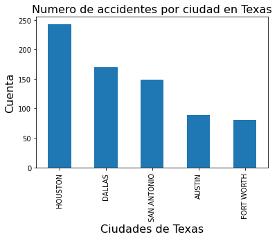

```python
#Escogemos solo el estado de texas y sus ciudades
texas_df = accidentData[["STATENAME", "CITYNAME"]][accidentData["STATENAME"] == "Texas"]

#Ocultamos la categoria NOT APPLICABLE de entre las ciudades
texas_df2 = texas_df[texas_df['CITYNAME'] != "NOT APPLICABLE"]

#Agrupamos y contamos el numero de accidentes por ciudad
texas_ciudades = texas_df2.groupby("CITYNAME").size().sort_values(ascending=False).head(5)

#Graficamos la cuenta de accidentes por ciudad en Texas
ax = texas_ciudades.plot.bar()

ax.set_title("Numero de accidentes por ciudad en Texas", size = 16)
ax.set_xlabel("Ciudades de Texas", size = 16)
ax.set_ylabel("Cuenta", size = 16)
```

### California

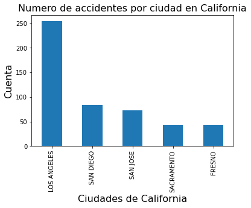

```python
#Escogemos solo el estado de texas y sus ciudades
cali_df = accidentData[["STATENAME", "CITYNAME"]][accidentData["STATENAME"] == "California"]

#Ocultamos la categoria NOT APPLICABLE de entre las ciudades
cali_df2 = cali_df[cali_df['CITYNAME'] != "NOT APPLICABLE"]

#Agrupamos y contamos el numero de accidentes por ciudad
cali_ciudades = cali_df2.groupby("CITYNAME").size().sort_values(ascending=False).head(5)

#Graficamos la cuenta de accidentes por ciudad en Texas
ax = cali_ciudades.plot.bar()

ax.set_title("Numero de accidentes por ciudad en California", size = 16)
ax.set_xlabel("Ciudades de California", size = 16)
ax.set_ylabel("Cuenta", size = 16)
```

### Florida

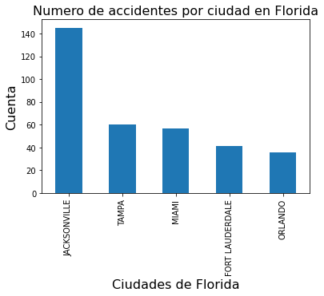

```python
#Escogemos solo el estado de texas y sus ciudades
florida_df = accidentData[["STATENAME", "CITYNAME"]][accidentData["STATENAME"] == "Florida"]

#Ocultamos la categoria NOT APPLICABLE de entre las ciudades
florida_df2 = florida_df[florida_df['CITYNAME'] != "NOT APPLICABLE"]

#Agrupamos y contamos el numero de accidentes por ciudad
florida_ciudades = florida_df2.groupby("CITYNAME").size().sort_values(ascending=False).head(5)

#Graficamos la cuenta de accidentes por ciudad en Texas
ax = florida_ciudades.plot.bar()

ax.set_title("Numero de accidentes por ciudad en Florida", size = 16)
ax.set_xlabel("Ciudades de Florida", size = 16)
ax.set_ylabel("Cuenta", size = 16)
```

En estas tres gráficas podemos visualizar las ciudades donde más accidentes ocurren, pero hay que tomar en cuenta que no estamos porcentuando por la población, por lo que no podemos sacar muchas conclusiones.

### Dicretización

Discretamos las siguientes variables para la utilización en la creación de modelos.

Utilizamos la discretización con el método de partición basado en el algoritmo de k-means en la variable VE_FORMS que indica el numero de vehiculos implicados en un accidente.

```python
accidentData['VE_FORMS'].describe()
```

```
count    33244.000000
mean         1.541541
std          0.853559
min          1.000000
25%          1.000000
50%          1.000000
75%          2.000000
max         59.000000
Name: VE_FORMS, dtype: float64
```

Lo realizamos con k-means porque las distancias entre valores son grandes. Como vemos el valor máximo es 59 y la media es de 1.54.

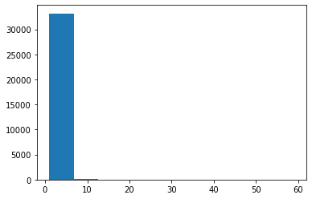

|  | VE_FORMS_DIS |
| --- | --- |
| 0 | 0.0 |
| 27 | 1.0 |
| 25413 | 2.0 |

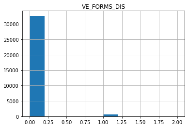

```python
#Importamos la libreria
from sklearn.preprocessing import KBinsDiscretizer

# histograma de los datos originales
plt.hist(accidentData['VE_FORMS'])
plt.show()

#Discretizamos la variable VE_FORMS que tiene el numero de vehiculos en movimiento implicados en 3 intervalos.
VE_FORMS_DIS = KBinsDiscretizer(n_bins=3, encode='ordinal',
                           strategy = "kmeans").fit_transform(accidentData[['VE_FORMS']])

#Convertimos el array en dataframe
VE_FORMS_DIS = pd.DataFrame(VE_FORMS_DIS)
VE_FORMS_DIS = VE_FORMS_DIS.rename(columns = {0: 'VE_FORMS_DIS'})

# Histograma de los datos transformados
VE_FORMS_DIS.hist()

#Vemos los valores en que han sido discretizados.
VE_FORMS_DIS.drop_duplicates()
```

Podemos observar que al escoger 3 intervalos, los valores son transformados en 0.0, 1.0 y 2.0.

Ahora vamos a realizar la discretizacion de la variable PVH_INVL la cual indica el numero de vehicuos estacionados implicados, utilizando el mismo método anterior, el método de partición basado en el algoritmo de k-means.

```python
accidentData["PVH_INVL"].describe()
```

```
count    33244.000000
mean         0.040849
std          0.288168
min          0.000000
25%          0.000000
50%          0.000000
75%          0.000000
max         11.000000
Name: PVH_INVL, dtype: float64
```

Como podemos observar sigue existiendo gran distancia entre los valores como en el caso de la variable con vehiculos en movimiento implicados, siendo en este caso el máximo valor el 11 y la media 0.04. Por lo tanto, usamos el método de partición basado en el algoritmo de k-means.

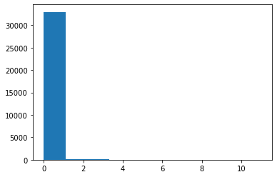

|  | PVH_INVL_DIS |
| --- | --- |
| 0 | 0.0 |
| 99 | 1.0 |
| 2755 | 2.0 |

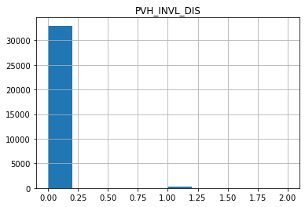

```python
# histograma de los datos originales
plt.hist(accidentData['PVH_INVL'])
plt.show()

#Discretizamos la variable VE_FORMS que tiene el numero de vehiculos en movimiento implicados en 3 intervalos.
PVH_INVL_DIS = KBinsDiscretizer(n_bins=3, encode='ordinal',
                           strategy = "kmeans").fit_transform(accidentData[['PVH_INVL']])

#Convertimos el array en dataframe
PVH_INVL_DIS = pd.DataFrame(PVH_INVL_DIS)
PVH_INVL_DIS = PVH_INVL_DIS.rename(columns = {0: 'PVH_INVL_DIS'})

# Histograma de los datos transformados
PVH_INVL_DIS.hist()

#Vemos los valores en que han sido discretizados.
PVH_INVL_DIS.drop_duplicates()
```

De igual manera que en el caso anterior, los valores en los que se discretiza son 0.0, 1.0 y 2.0, al haber determinado la discretización para 3 intervalos.

## Conclusiones

La mayoría de accidentes tiene al menos un muerto, pero de estos la mayoría no involucra peatones, ciclistas, personas a caballo, sino principalmente al vehículo motorizado. Y es el caso, de que los accidentes en su mayoría involucran a un solo vehículo.

En el caso de tipo de infrastructura presente en los accidentes, analizamos el tipo de intersecciones donde suceden. Aunque en su mayoría los accidentes no suceden en intersecciones, un número menor pasan especificamente en intersecciones de 4 vías, seguido por intersecciones de tipo T. En el caso de proximidad a cruces, de igual manera, vemos que la mayoría de los accidentes no suceden en cruces, pero el tipo de cruce donde más suceden son las intersecciones.

Desde una perspectiva geográfica, vemos que mas de la mitad de accidentes suceden en áreas urbanas con el 55% y en areas rurales con el 44%. Además, tomamos los tres estados con más numero de accidentes y visualizamos las ciudades de cada estado. Sin embargo, cabe recalcar que no se puede porcentuar por la población (no tenemos esta variable en el conjunto de datos), por lo que no nos podemos apresurar a sacar conclusiones.

Finalmente, discretizamos las variables con el número de accidentes con vehiculos en movimiento involucrados y accidentes con vehiculos estacionados involucrados. Estos resultados se puede utilizar en la creación de un futuro modelo.